# Exploring transit service level impacts on the spatial and temporal patterns of micromobility travel - statistical tests

Dr James Reynolds

2024-05-03

# Introduction

PTRG is preparing a paper on exploring transit service level impacts on the spatial and temporal patterns of micromobility travel. Analysis has already been completed in R to generate hourly transit Supply Index (SI) values for Greater Melbourne for this project, and a draft paper has been prepared. The addition of results from statistical tests might enhance the paper, but such analysis is yet to be completed.

This working note shows the results of the statistical tests to be included in the paper.

# Methods

Data was received from Graham in a series of excel files. These are reviewed and processed using the ggstatsplot package(Patil 2021).

Patil, Indrajeet. 2021. “Visualizations with statistical details: The ’ggstatsplot’ approach.” *Journal of Open Source Software* 6 (61): 3167. https://doi.org/10.21105/joss.03167.

# Results

## Rail versus non-rail - averages

Figure 8 of the draft paper presents the “Absolute difference in average service level (SI) scores between each trip end of all e-scooter trips and its variation with e-scooter trip length (km) average service”. Comparing these gives:

Distribution of average absolute difference in SI Score for rail and non-rail related trips, grouped by trip distance

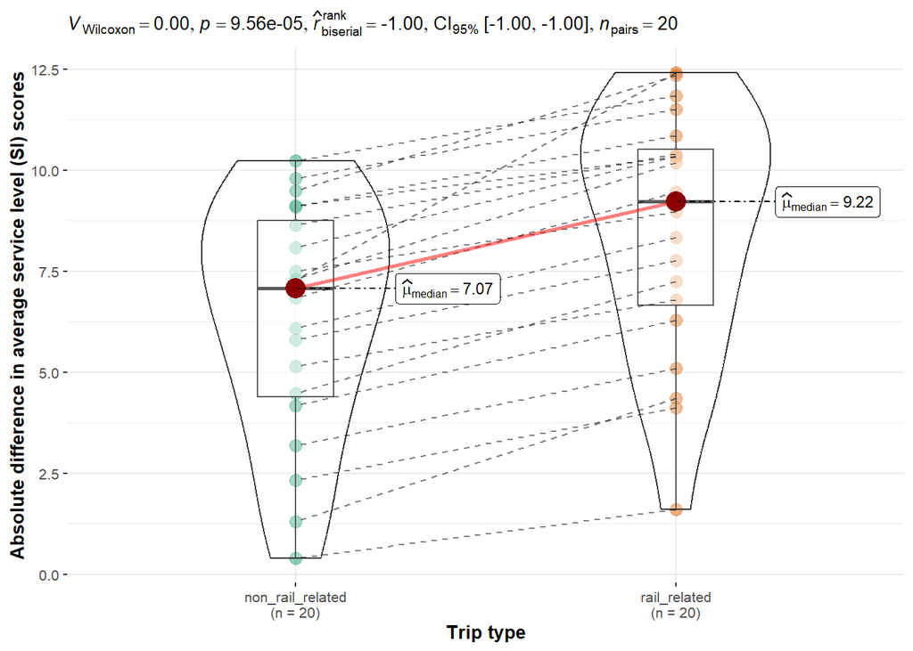

As shown above, there is a statistically significant difference in the absolute difference in average service level (SI) scores between each trip end.

## Rail versus non-rail - all

The above figure, and Figure 8 in the draft paper, appear to be based on average values around distances of 0, 0.08, 0.27, 0.44, 0.58, etc. This section instead examines the entire dataset. The following compares absolute difference in SI score for all rail and non-rail related trips.

Absolute difference in SI Score for rail and non-rail related trips

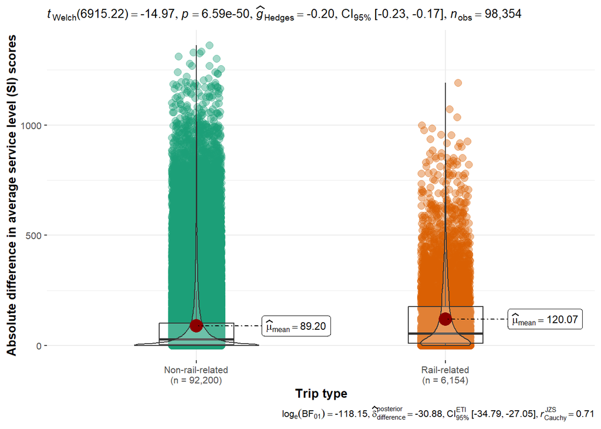

As shown above, there is a statistically significant difference in the absolute difference in SI Score between the rail and non-rail-related trips.

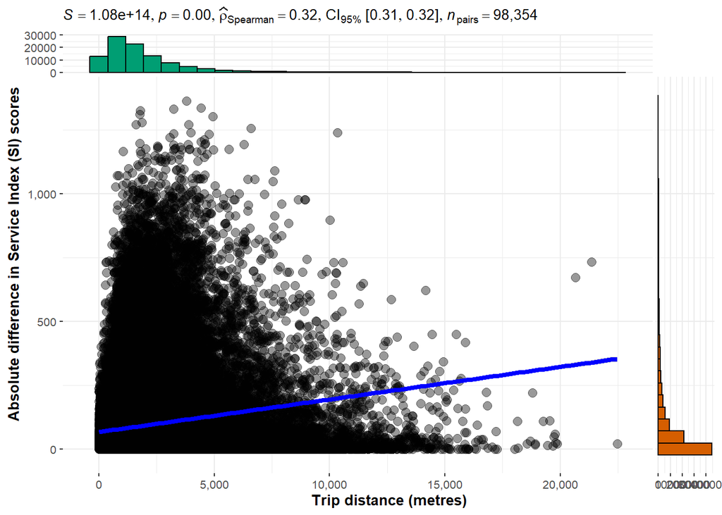

Absolute difference in SI Score and trip distance, all trips

As shown above, there is a statistically significant relationship between trip distance and absolute difference in SI score.

Absolute difference in SI Score and trip distance, rail-related and non-rail-related trips

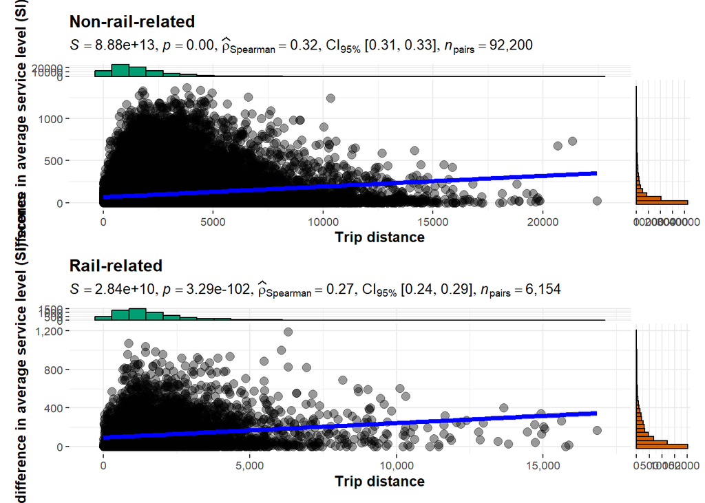

As shown above, there are statistically significant relationships between trip distance and absolute difference in SI score across both the non-rail and rail-related groups.

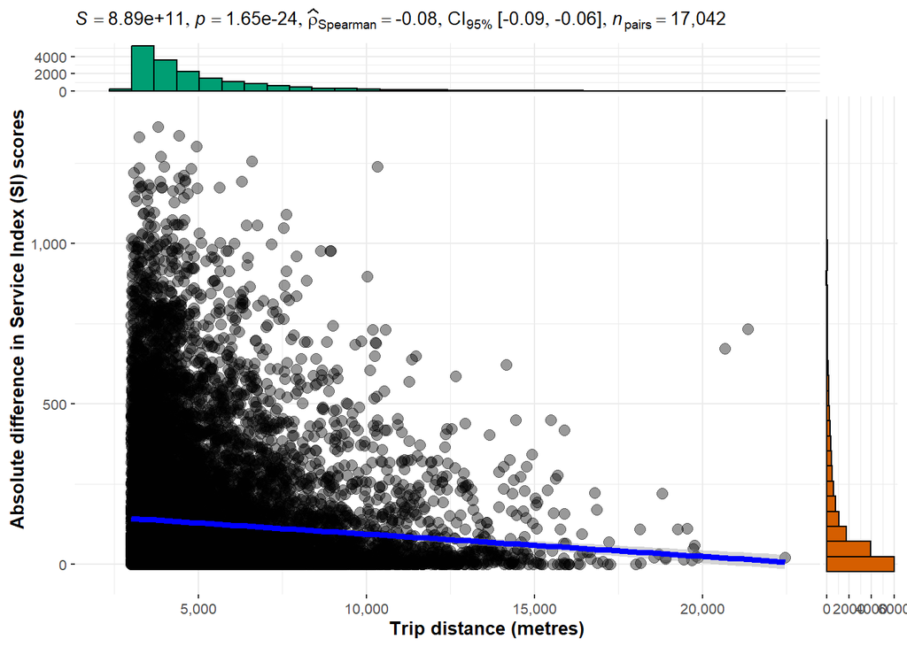

Absolute difference in SI Score and trip distance, trips over 3kms

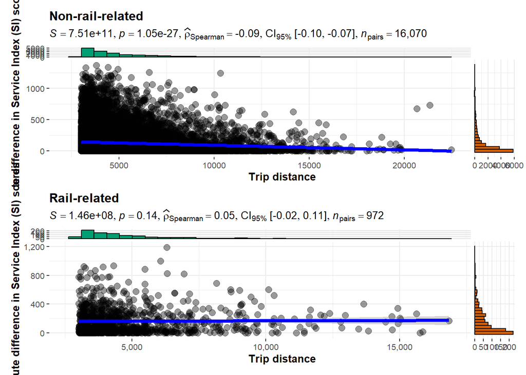

Absolute difference in SI Score and trip distance, trips over 3kms

As shown above, there is a statistically significant relationship between trip distance and absolute difference in SI score for trips over 3km, with this being a negative relationship. A similarly statistically significant relationship is present for non-rail-related trips over 3km, but not for rail-related trips.

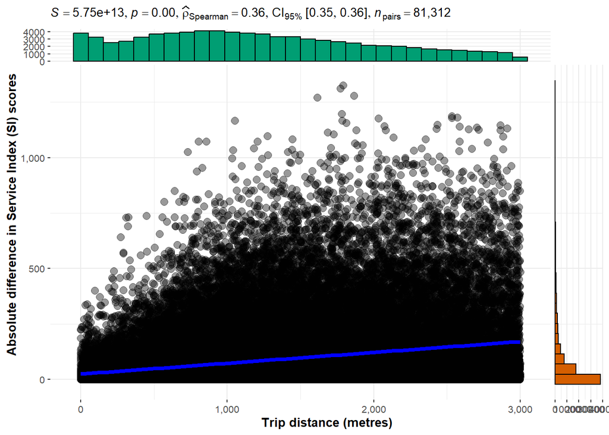

Absolute difference in SI Score and trip distance, trips less than or equal to 3kms

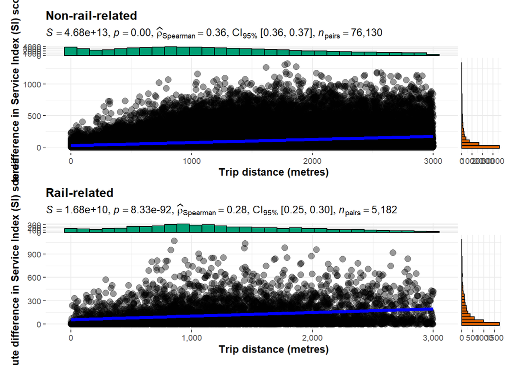

Absolute difference in SI Score and trip distance, trips less than or equal to 3kms

As shown above, there are statistically significant relationships between trip distance and absolutie difference in SI score for trips less than or equal to 3kms, across all trips, non-rail-related trips and rail-related trips.

## Trip volume and density versus SI (Figure 4)

The data behind Figures 4 and 6 appears to be in the “ChoroplethData.xlsx” file. Data is separated by SA1 (rows)

Aggregate SI score and Total Trip Volume

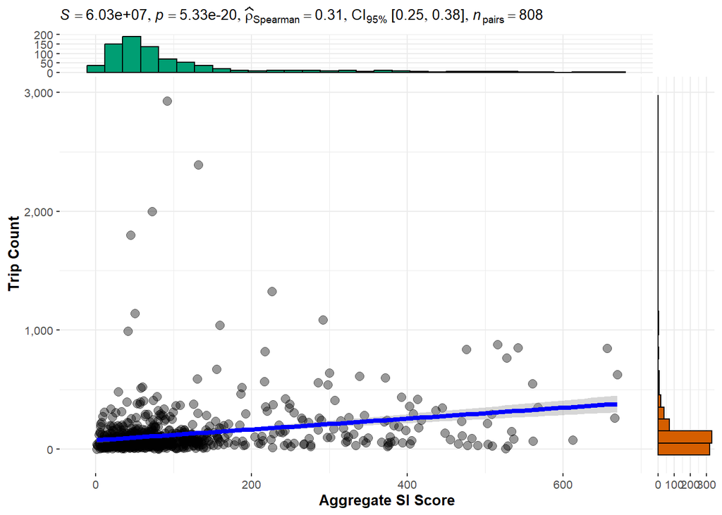

The above indicates that there is a statistically significant relationship between Aggregate SI score and trip count.

Aggregate SI Score and Total Trip Volume Density

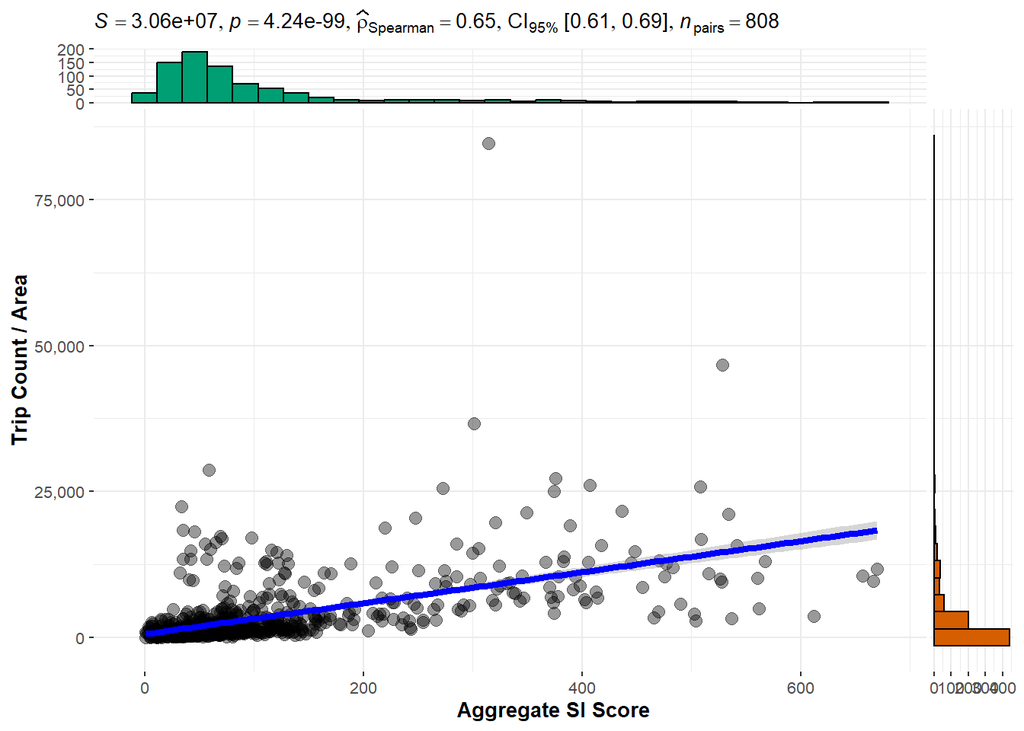

The above indicates that there is a statistically significant relationship between Aggregate SI score and Trip Volume Density.

## Rail-related trip volume and density versus SI score (draft paper Figure 6)

Aggregate SI Score and Rail Related Trip Count

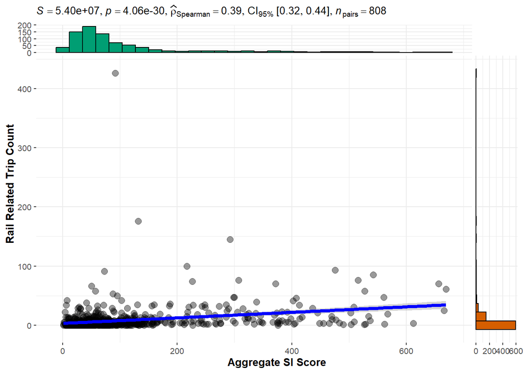

The above indicates that there is a statistically significant relationship between Aggregate SI score and trip count.

Aggregate SI Score and Probability of Rail Connection

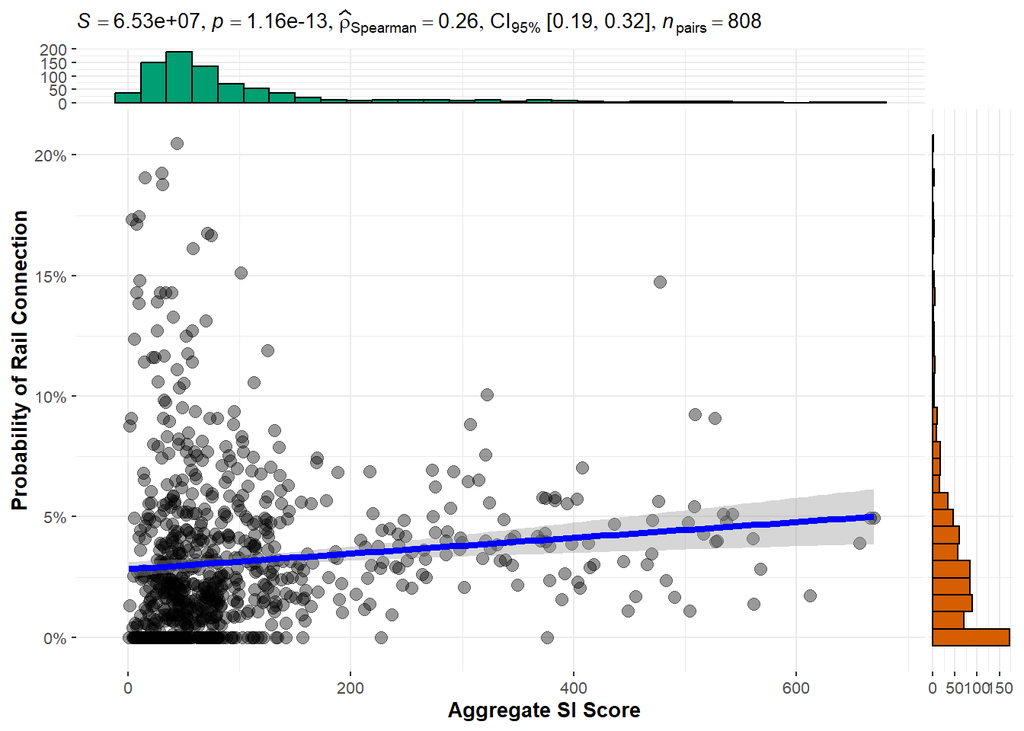

## More trips starting at stations than ending there (draft paper Section 4.3.1)

Comparing rates of station proximity at trip start and end points

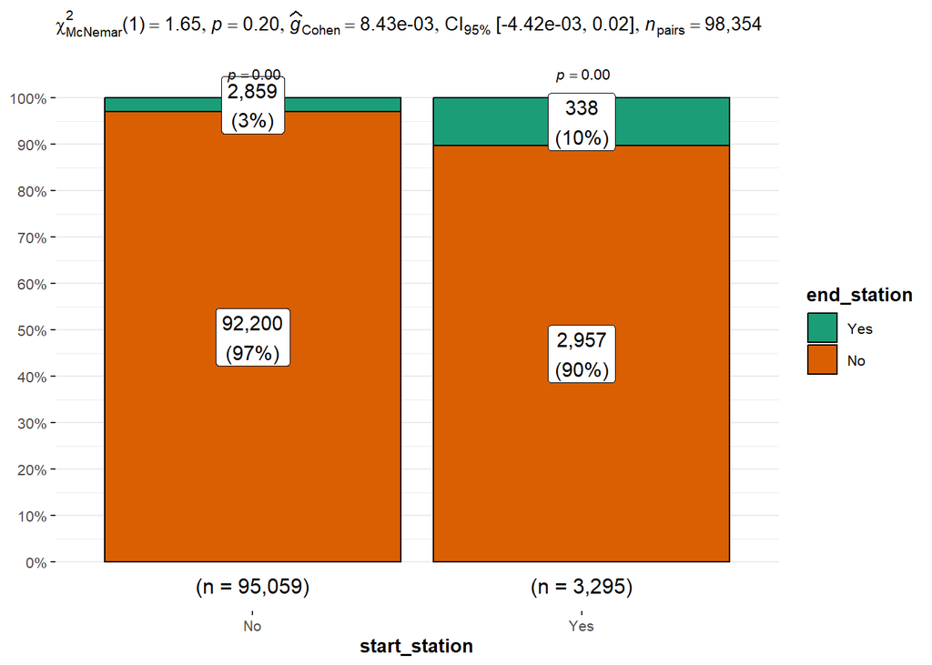

Comparing rates of station proximity at trip start and end points

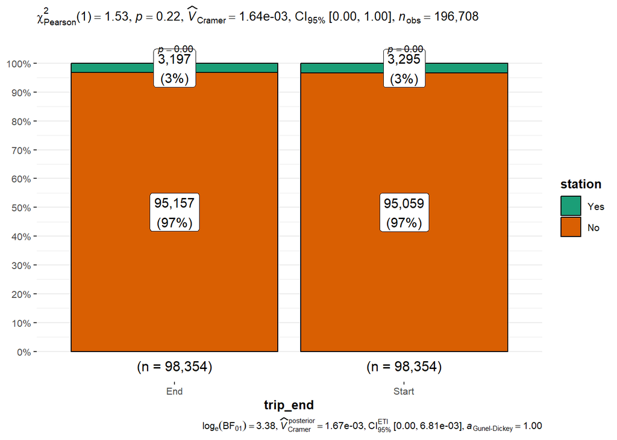

The above indicates that there is no statistically significant difference between whether a trip starts at a station or not and whether it ends at a station or not.

## Share of trips starting and/or ending at a station - weekends versus weekdays (Section 4.3.1)

Share of trips starting at a railway station, by day type

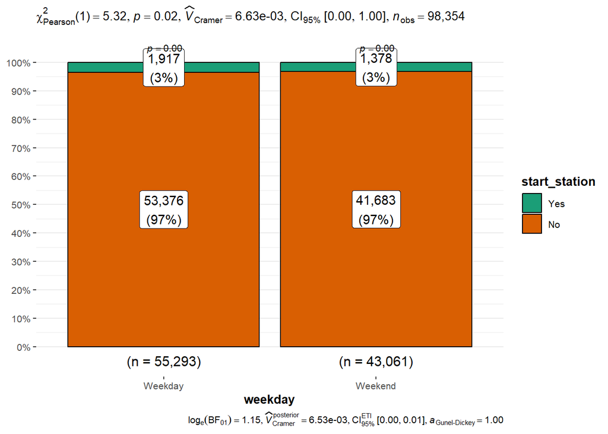

As shown above, there is a statistically significant relationship between whether a trip starts at a railway station and whether it is a weekday or weekend.

Share of trips ending at a railway station, by day type

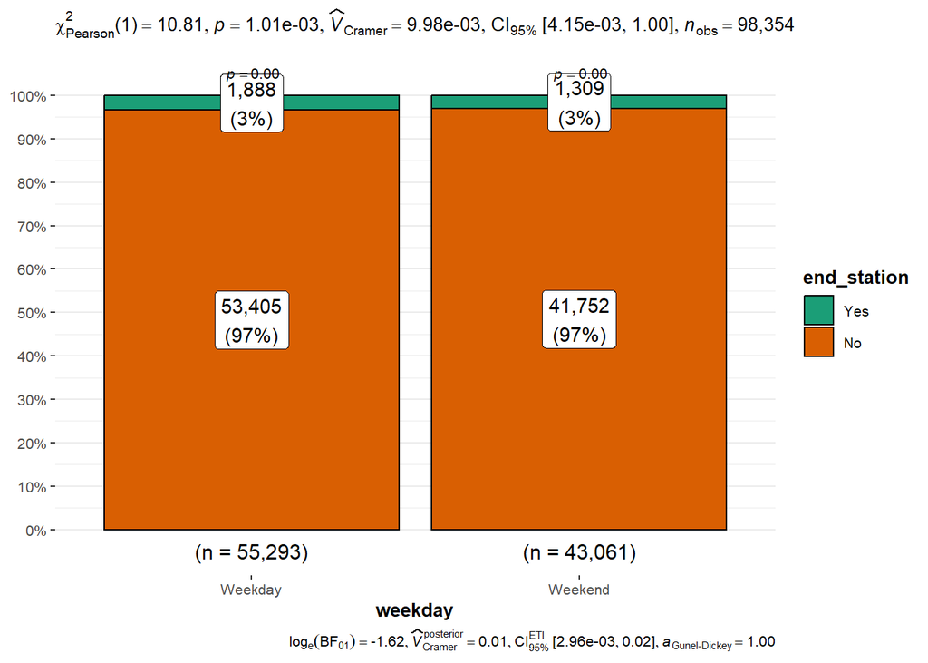

As shown above, there is a statistically significant relationship between whether a trip ends at a railway station and whether it is a weekday or weekend.

Share of trips starting and ending at a railway station, by day type

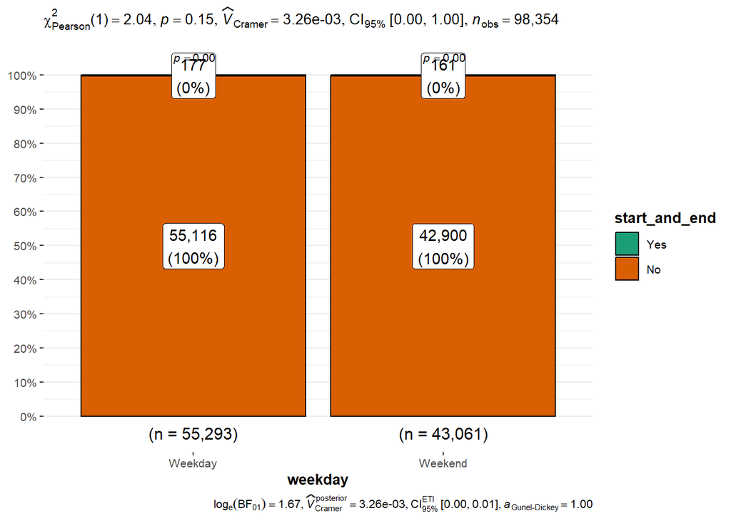

As shown above, there is no statistically significant relationship between whether a trip starts and ends at a railway station and whether it is a weekday or weekend.

## Trips are longer on weekends than weekdays (Draft paper Section 4.3.1)

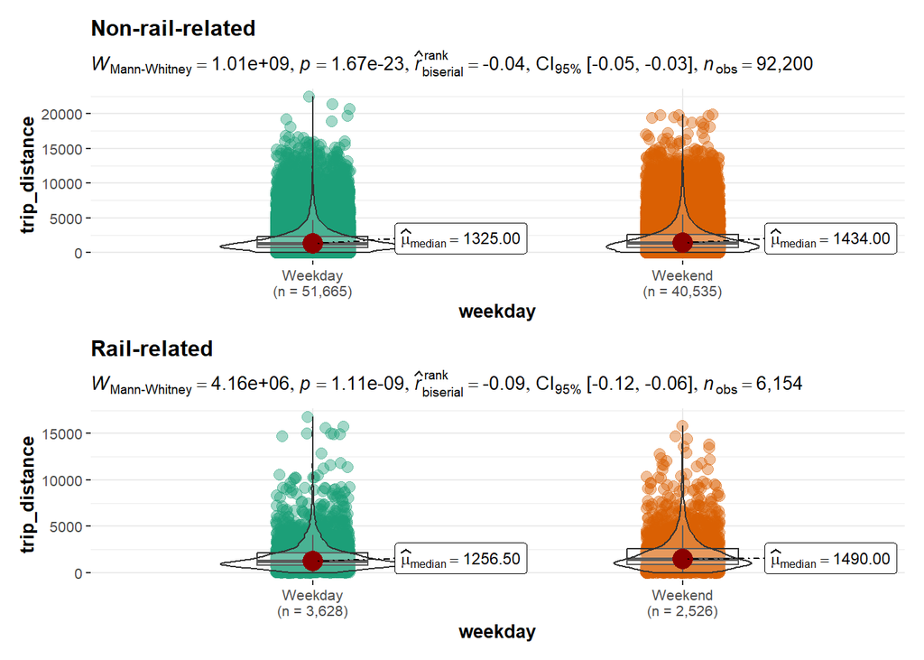

As shown above, there are statistically significant relationships between trip distance and and whether it is a weekday or weekend across both the non-rail-related and rail-related trip groupings.

Distance by day type, all trips

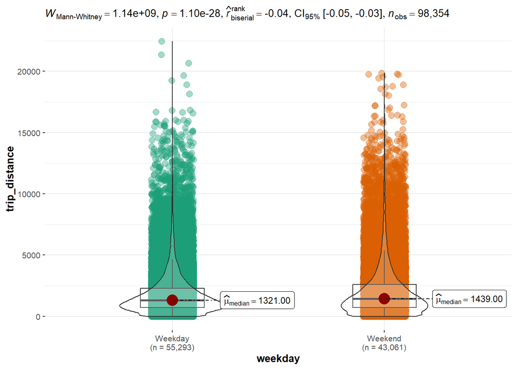

As shown above, there are also a statistically significant relationship between whether a trip distance and whether it is a weekday or weekend, across all trips

## Rail-related trips are the same length as non-rail-related trips (Draft paper Section 4.3.1)

Distance by trip type

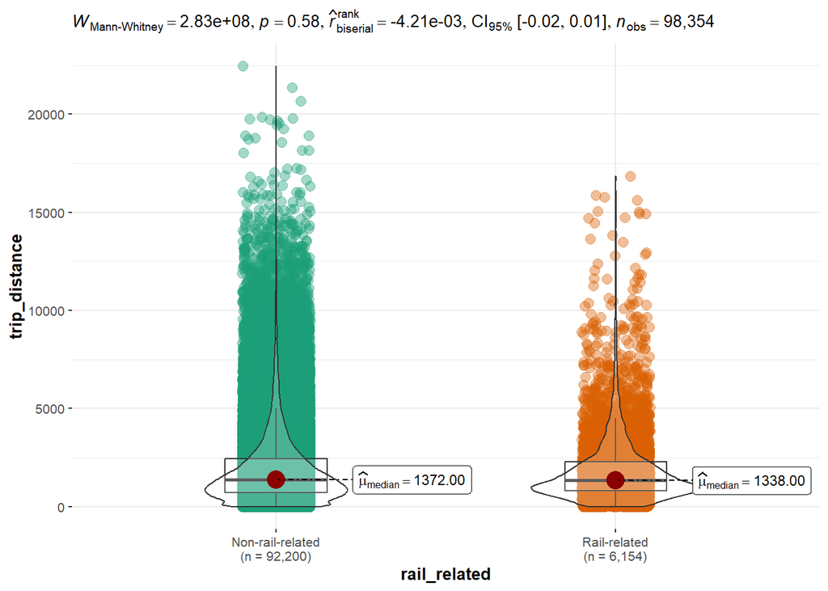

As shown above, there is no statistically significant difference in trip length between rail-related and non-rail-related trips.

## Fishermans Bend stands out (Draft paper Section 4.3.3)

Fishermans Bend (SA1 area 20605151104) is noted as having a different pattern, especially related to rail-related trips being a higher than might otherwise be expected. In the below, this is explored further.

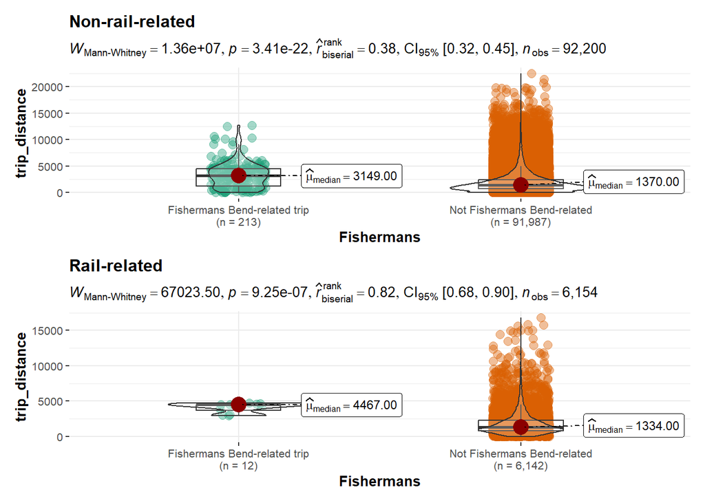

As shown above, there is a statistically significant relationship trip distance and whether a trip is Fishermans Bend related, for both rail related and non-rail related trips.

Trip distance, Fishermans Bend vs non-Fishermans bend trips, all trips

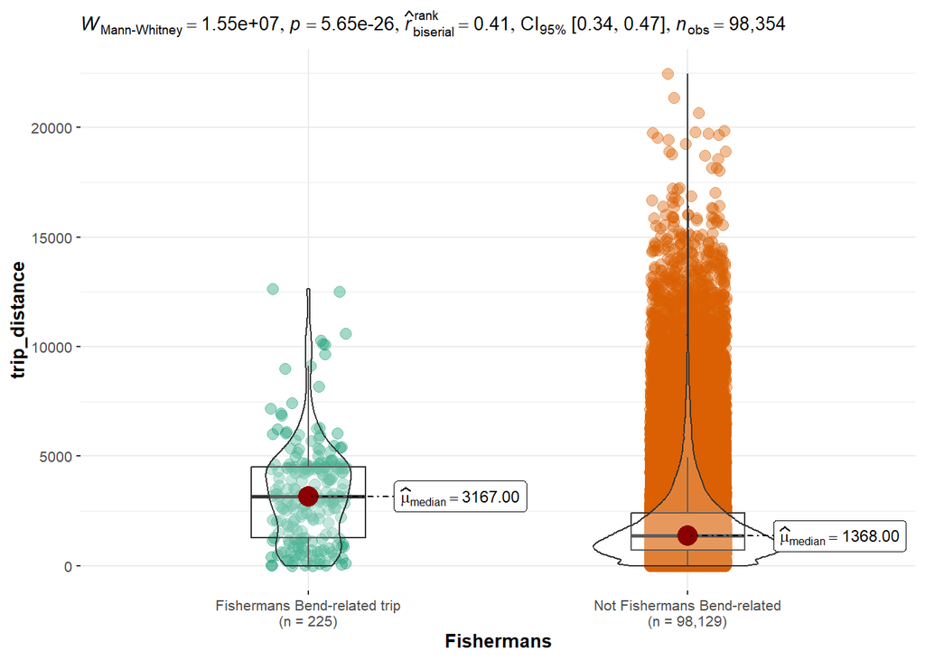

As shown above, there is also a statistically significant relationship trip distance and whether a trip is Fishermans Bend related across all trips.